# Value

Where, how, when, what, why

2026-04-08

Value. The word “value” is used quite often in public discourse. “Value creation” they say. Politicians, businesses, entrepeneurs, and innovators often talk about “creating value”, as if it is obvious what they are talking about. Back when I was studying philosophy and economics we discussed value too: labour theory of value, use value, instrumental value, intrinsic value, market value, exchange value. Money is said to be a store of value. Prices are said to reflect the valuation of things. A natural question then is: what is value? What is valuable? And then: why is this thing or that thing valuable? But before one even gets there, there are other questions that need to be asked first.

# Where is value?

Suppose all humans on earth ceased to exist. Would there be value left? I think the answer is yes, but it would be non-human value, anchored in other beings. In considering this possibility of non-human value we quickly see that whenever we talk about value in everyday terms, we most likely mean *human* value. That is, we’re talking about things that we consider relevant to our own species. So, leaving non-human value undiscussed, we can say that value is anchored in the human mind. I say *anchored* because it is still not fully clear *where* it is.

Let’s make it more concrete. Consider coffee. Suppose I say my cup of coffee has value. Where is the value, physically? In the coffee? In my brain? In the brains of those who produced the coffee? Right now there are probably coffee plants out there, producing unharvested and unused cherries. If we only think about the coffee that could have been extracted from them (not about photosynthesis, soil fertilisation, or aesthetics), then we can say that those cherries have no (human) value. So the value that I am talking about cannot be only in the coffee. And what about the producers? What if they don’t manage to sell the coffee? Do they still value it? Is it still valuable to them? Maybe they looked at it, smelled it, talked about it, dreamt about earning money from it. Maybe they derived some non-monetary value from the coffee before it was sold - value that exists regardless of the sale.

And then there is me: I look at the bag and the price, I form an intent, and buy the beans. I hold the bag, feeling it, smelling the beans, anticipating the brewing. Already now I am deriving value from it. Eventually I grind the beans and brew the cup. When I set about taking the first sip I have already experienced the sight, sound, smell, and touch. Finally I taste it, savour the heat, the taste, the aroma, and swallow. The caffeine makes its way into my bloodstream and into the brain. After a while the sensory experience fades away, the caffeine is broken down, and the events that passed are captured in memory. At will, I can recall fragments of what happened. I can value the memory too.

I do a fair amount of mental processing throughout this process of buying, preparing, and drinking the cup of coffee. Even if I did all of it without discussing or sharing any step along the way with someone else, there are social aspects to the experience. The whole process happens in a cultural context. People talk to one another about coffee, cultivars, preparation and roasting methods. Companies that are involved in the process mark their product with their brands. People start to relate to one another through all this. Maybe you feel a sense shared understanding with other people who consume the same coffee in similar ways. This relation to others may be either real or imagined. I might sit alone, drinking my coffee while subconsciously awakening a trace cultural belonging, or imagined relations, in my mind.

So value is:

- in one or more brains (or mind)
- linked to objects (external or internal objects, behaviours, processes, systems)

# How is value?

Now that we have a more conrete sense of *where* value is, we can investigate how it originates. Based on the previous section one can define a simple model for how value is created:

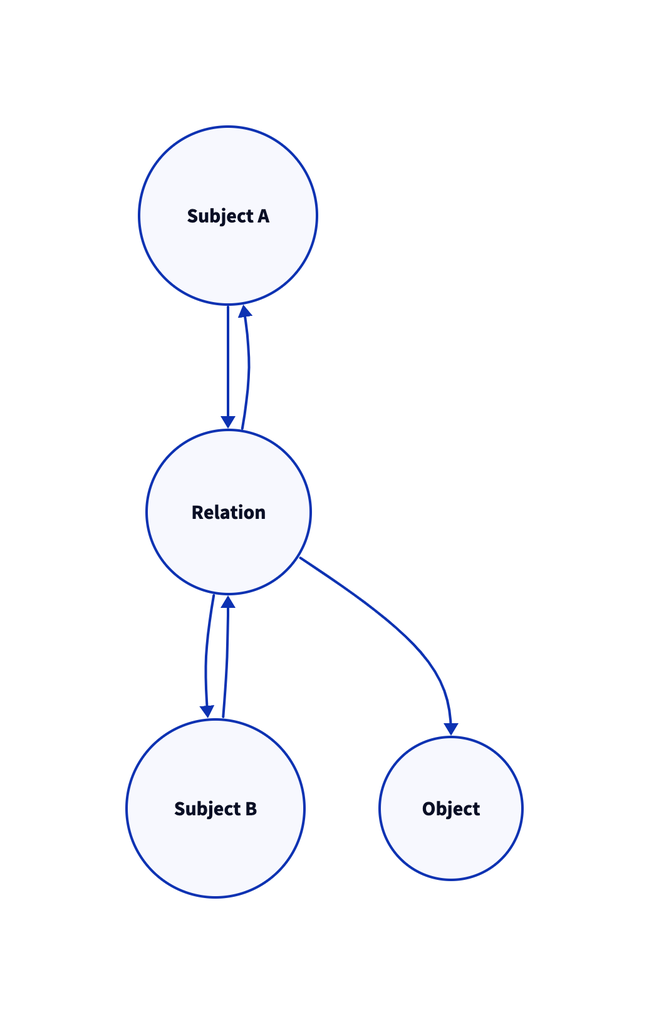

In the simplest case, a subject forms a mental relation to an object and values it. I drink coffee and I like it. Another subject can do the same. One subject can form a relation to another subject which has formed the same relation, and vice versa: two people relate to one another over the fact that they both value the same thing. I talk to another person talk about how we like coffee. It is also possible for one subject to value what another subject values *without* having created value from their own relation to it. Another person explains the value of coffee to me, and I start drinking it.

Going further still, it is conceivable that two subjects relate to one another based on their mutual valuation, without either of them having established their own relation to the object of mutual valuation. You and I heard somewhere that coffee is good, we both drink it together. In the pathological case, both of us might actually dislike coffee, but due to the mutual perception of both valuing it, we might persist in drinking it anyways. Subjects can also be objects: people can value other people for one reason or another.

Going yet further down the rabbit-hole, people can value that others value their relation to the object, without actually valuing the object or their relation to it. Or, they can value others’ *perceived* valuation of their valuation, without ever observing the reciprocal valuation. These dynamics can devolve into a large-scale performative game in which nothing really happens other than the maintenance of perceived mutual valuation. It becomes a valuation game. I want to derive value from others valuing what I value. They want the same. So, in order to receive that validation, I give it to others, regardless of whether I actually value what they do. Knowing that they must reciprocate in order to receive validation themselves, they do the same. I cannot really know whether, how, or to what extent others value what I do, but I intend to play the game successfully, so I block that thought and decide to just value whatever feedback I get. We play the game because we value playing the game. We value the game because we play the game. The game is valuable because many people play it.

The more people are involved, the more abstract the object, and the more indirect the inter-subjective relations are the more complicated it gets. I value this aspect of that process, you value that aspect. We value the same part in different ways. We value the same part in the same way for different reasons. We value the same thing in the same way for the same reasons with different intensities, or equal intensity, but relate to one another differently about it. Can two minds construct congruent states?

# When is value?

When does one start doing something, and when does one stop? I’ve had bouldering projects that lasted 10 years (and more) from the moment when I first saw a boulder until I finally climbed it. And when I am done climbing it I remember the process, spend time recalling it and reflect on it at will. I might discuss these recollections with a friend who also knows about the boulder from time to time. The general observation here is that there is no such thing as “just doing something”. In the same way that the act of *seeing* is shaped by what you know, your attitudes, state of mind and goals, relating to something in order to value it happens alongside of and as part of other mental and physical processes.

Time plays a part in value in at least two ways: the brain, the substrate of the mind, is a physical system that changes over time, and we frame our experiences as time-based sequences. Regarding the substrate, cognitive activity in the brain today has an effect on cognitive activity tomorrow. Depending on what that cognitive activity is, and what behaviour it initiates, the effect can be either insignificant, life altering, or anything in between. Some experiences are more durable and persistent than others. Regarding the framing of experience, it is clear that we can imagine, anticipate, expect, experience, remember, contemplate the actual event which forms the core of a specific value creation. Nothing happens in isolation, and value stretches into the remembered past and the imagined future. Nonetheless, just like all cognitive activity and phenomena in general, there is a time when the event itself occurs, when we *relate*.

So, value exists now. It might refer to the past, present or future, but the subject experiences the relation as valuable when all phenomena are experienced: *now*.

# What is value?

Value is a time-dependent, socially contextualised mental relation between a subject and an object, that can potentially be anything that the mind can relate to and can be constructed in a myriad of different ways. Such mental relations are experienced, recognised as valuable, and form a part of the processes that define the lives of social organisms such as human beings.

This may sound vague and abstract but it clarifies a couple of things: value is not an objective quality, an independent property of the world, or a part of reality “out there”. Something can be both valuable and useless at the same time, depending on who you ask. The same thing can be valued now, and be considered worthless in the future, or the other way around. Value is not one thing, and does not have one function.

I suspect that value creation, to the extent that it is distinctive mental and perceptual activity, involves several brain functions, regions, and systems. I also suspect that it involves dopamine processing in our reward systems. When we value something, there is a sense of satisfaction, a feeling that a need has been met, a sense of positive reward that accompanies the act of doing so. It is probably also deeply involved in how we make sense of the world, and how we create meaning in our lives. As such it plays a very important role in our lives. We create value because we need it.

# Why bother?

Humans depend on one another to survive and to thrive. Relationships are established in the context of this inter-dependence. The need to collaborate on the solution of basic needs creates the conditions in which social structures, culture, technology and value creation emerges. But not all social constellations are benign. Leaving aside the more extreme and insidious examples of harmful social constructs, we can simply remember that some people are opportunistic, and that there is no automatic guarantee that the social systems and technologies that emerge and affect your life will have a benign effect on you. In the ever changing technological and global world we currently inhabit, physical and behavioural traits that we evolved long ago may suddenly become pitfalls to ourselves and weaknesses that can be exploited by opportunistic individuals and systems. Our inherent drive to create value can be hijacked to become a detrimental force to ourselves. In addition to that, we can also make mistakes in our own valuations in the absence of exploitative surroundings.

For example, the combination of marketing and highly processed food might lead someone to eat themselves into obesity, or type 2 diabetes. In their minds they might simply be following the lead of their reward systems, valuing the impulses that come their way in accordance with their basic need for food. Each instance of food consumption might seem innocent and harmless when viewed in isolation, but the cumulative effect is devastating. You can literally eat yourself into depression or death.

In another example, by simply following curiousity and a need for social belonging someone might gradually descend into a digital echo chamber which radicalises their views. In some cases the adoption of conspiracy theories lead to the breakup of core relationships, and in more extreme cases it leads to violent behaviour. It might start with the simple valuation of information, interesting ideas, and conversation, the sum of which adds up to a pathological process for an individual life.

More subtle examples abound. In valuing comfort, convenience, and entertainment one might choose to sit on the couch and watch TV almost every night of the week. Valuing the same things, one might eat some snacks and drink some drinks while doing so. While sitting on the couch, the body is typically in a forward bend in the upper torso, which discourages deep diaphragmatic breathing. The nervous system might lose contact with the intercostal muscles necessary for proper breathing. A lack of oxygen accumulates in the body. Hanging the head forward consistently will shorten the muscles on the front of the neck, and strain the ones on the back of the neck. This might lead to headaches, or just constrianed movement in the upper body. Perhaps TV is a bit boring so one augments the sedentary experience with some scrolling on the phone, checking out whatever algorithmic feed is available at the time in the hope of triggering the desired dopamine rewards, slowly eroding the ability to concentrate even on entertainment. The exposure to bright flashing lights and emotionally charged subject matter might make it difficult to fall asleep. If one had been drinking alcohol, the quality of sleep deteriorates even further. Over time, distracted states of mind, unhealthy eating and drinking, low quality sleep, and lack of movement accumulate. The cumulative engagement in mildly detrimental behaviour results in essentially valuing the wrong things in life. The body and the mind become lesser versions of what they otherwise could have been. Eventually, it undermines your quality of life. The years are gone, the change is irreversible. Slowly, without any big tragedy, you undermine your own joy of life, and become someone who you do not wish to be.

The momentum inherent in the global techno capitalist consumer world is that you need to constantly accumulate new objects and new behaviours, and that you need to acquire more things to enhance your comfort and convenience in order to live a good life. We are surrounded by loud claims about value: you need to value this and buy that, and pay attention to all these things. In isolation, these look like harmless claims, but they should be treated with skepticism and caution. Nature is full of poisonous plants and fungi, dangerous animals and risky places and requires knowledge and skill to be navigated safely. Just so, the world is filled with vacuous and opportunistic claims about value that are detrimental to your own happiness and contentment. To live a good live in which you survive and thrive in healthy relationships with others requires knowledge and skill. Knowledge of your own tendencies to create value, the dubious nature of the world, and the skill to take control of your own value creation processes, moment-to-moment, and over time. Choose what you relate to, and how you do so with care.